# Run some checks

Villaseñor-Derbez J.C.

Updated on 2019-10-23

#Model for marine conservation with effort markets

We model a ten-patch discrete-time meta-population system, where Patch 1 is considering a spatial closure. Patches 1 - 9 opperate under a vessel-day schemePatches, and Patch 10 represents the high seas and other areas not managed under a VDS. The stock of fish in each country is relatively stationary within a single fishing season, but redistributes across all patches annually. The price of fish is $p$, and catchability is given by $q$. These parameters are held constant across patches.

##Fishery dynamics

In the absence of a reserve, the revenue for vessels in patch $i$ is given by $pqE_iX_i$, where $E_i$ and $X_i$ are effort (vessel-days) and stock size in patch $i$ at the beginning of a period. The cost of fishing in patch $i$ is given by $cE_i^\beta$, where $\beta = 1.3$ matches commonly-used cost functions.

Patch 1 considers a spatial closure by implementing a reserve as a fraction $R$ of the total patch ($R \in[0,1)$). Fish move within a patch based on $\theta$, where $\theta = 0$ implies no movement within the patch, and $\theta = 1$ implies that fish within the patch are well mixed during the fishing season. In this patch, revenues are given by $pqE_1X1(\theta + (1 - \theta)(1 - R))$. The parameterization of movement and reserve size imply that profit from fishing Patch 1 is given by:

$$\Pi_1(E_1,X_1,R) = pqE_1X_1\Omega_i-cE_1^\beta$$

With $\Omega_i = (\theta + (1 - \theta)(1 - R))$ being a parameterization that combines reserve size as a proportion of patch ($R = (0, 1)$) and within-patch fish movement ($\theta$). Under this parameterization, $\Omega_{i \not 1} = 1$ since only Patch 1 implements a reserve.

Profits from fishing in each Patch are:

$$\Pi_i(E_i,X_i) = pqE_iX_i\Omega_i-cE_i^\beta$$

The above equations imply that the marginal profit from the last unit of effort in a patch are given by:

$$\pi_1(E_1) = pqX_1\Omega_i - \beta cE_1^{\beta-1}
\label{eqn:marginal_profit}$$

In practice, the effort levels in each Patch are allocated by management (so $E_{1},\ E_{2},...,E_{9}$ are given) and the effort level on the high seas ($E_{10}$) is a result of open access dynamics. Therefore, we assume that effort continues to enter Patch 10 until the profit from the last unit of effort is exactly zero, indicating that $E_{10}$ is the value for which $\pi_{10}(E_{10}) = 0$. Setting Equation for $i = 10$ equal to zero and removing $\Omega_{10} = 1$ for simplicity, we can solve for $E_{10}$:

$$E_{10} = \left(\frac{pqX_{10}}{\beta c}\right)^{\frac{1}{(\beta - 1)}}
\label{eqn:effort_hs}$$

Under vds-operated patches, however, profits from marginal effort must equate the cost of fishing in the patch. Therefore vessel-day price for patches under vds ($i = (1, 9)$) is given by:

$$\pi(E_i) = pqX_i\Omega_i - \beta c E_i ^{\beta - 1}$$

We can solve for $E_i$ and obtain:

$$\begin{equation}
\begin{split}
\pi_i + \beta c E_i ^{\beta - 1} &= pqX_i\Omega_i \\
\beta c E_i ^{\beta - 1} &= pqX_i\Omega_i - \pi_i \\
E_i ^{\beta - 1} &= \frac{pqX_i\Omega_i - \pi_1}{\beta c} \\
E_i &= \left(\frac{pqX_i\Omega_i - \pi_1}{\beta c }\right) ^ {\frac{1}{\beta - 1}}
\end{split}
\label{eqn:demands}
\end{equation}$$

Therefore, total allowable effort in the fishery is given by:

$$\bar{E} = \sum_{i = 1}^9\left(\frac{pqX_i\Omega_i - \pi}{\beta c }\right) ^ {\frac{1}{\beta - 1}}
\label{eqn:Ebar}$$

## Stock dynamics

Patch-level harvest is then determined by effort and stock size:

$$H_i = qE_iX_i\Omega_i
\label{eqn:harvest}$$

Therefore, escapement in patch $i$ is the difference between initial stock size and harvests given by $e_{it} = X{it} - H_{it}$ and total escapement is $e_t=\sum_{i=1}^{10}e_{it}$. The entire stock then grows logistically according to:

$$X_{t+1} = e_t + e^{r \times \frac{e}{K}}
\label{eqn:grow}$$

Where $r$ and $K$ are species-specific intrinsic growth rate and carrying capacity.

After the stock grows, a constant and patch-specific fraction $f_i$ of the total stock redistributes to patch $i$, so:

$$X_{it+1} = f_iX_{t+1}
\label{eqn:disperse}$$

## Vessel-day revenues

The vessel-day price that a country charges is given by $\pi_i$ from Eqn . Therefore, patch-level license revenues are given by:

$$\omega = \pi_iE_i
\label{eqn:license_revenue}$$

Equation shows that low values of $\theta$ and $R > 0$ would increase escapement, which would lead to an increase in stock size (Equation ) and a benefit to all the other patches. But this would also cause the stock in the high seas ($X_{10}$) to increase, leading to an increased effort being allocated to the high seas (Equation ) and a loss of these potential rents. Thus, the spillover benefits of increasing $R$ are never completely captured.

## Allocation rules

In the second scenario above, effort from a patch with conservation is traded to other patches. This means that its allocation will decrease as purse seine effort in its EEZ is reduced. After solving for the new equilibrium for each combination of $R$ and $\theta$, we project the fishery 50 years in time. At the end of every time, vessel-days are allocated to each patch based on the following rule:

$$E_i^* = \alpha \left(\frac{\sum_{\tau = 0}^{\hat{\tau}}E_{i,t-\tau}}{\bar{E}\hat{\tau}} \right) +
(1 - \alpha) \left(\frac{\sum_{\tau = 0}^{\hat{\tau}}X_{i,t-\tau}}{\bar{X}\hat{\tau}} \right)$$

Where $\alpha$ is a weight on historical effort ($E_i$) and $1-\alpha$ is the weight in historical biomass ($B_i$). We use $\hat{\tau}= 7$ to obtain a moving mean of 7 years for these measures. The difference between allocated days ($E_i^*$) and used days (determined by Eq: ) for patch 1 are the sales. We then calculate vessel-day revenues to each country over the 50-year time horizon and compare them to a case where there is no reserve and allocations are based solely on biomass ($\alpha = 0$).

# Setup

## Load packages and functions

```r
# Load libraries
library(startR)
library(here)
library(cowplot)
library(magrittr)
library(tidyverse)

# Load functions
source(here("scripts", "3_model", "E_vec_fxn.R"))
source(here("scripts", "3_model", "pi_of_E.R"))
source(here("scripts", "3_model", "max_Ei.R"))

# Some housekeeping
update_geom_defaults("point",
                     list(
                       fill = "steelblue",
                       color = "black",
                       shape = 21,
                       size = 3
                     ))


update_geom_defaults("line", list(color = "black",
                                  size = 1))

theme_set(startR::ggtheme_plot(font_size = 8))
```

## Define parameters

```r
# Reserve properties
theta <- 1
R <- 0

# Bio
MSY <- 1875600 # 50th percentile from MSY in table 8 of SA (https://www.wcpfc.int/node/27490)
Bmsy <- 1628000 # 50th percentile from SBmsy in table 8 of SA (https://www.wcpfc.int/node/27490)
K <- 6876526 # 50th percentile from SB_f0 in table 8 of SA (https://www.wcpfc.int/node/27490)
Bc_B0 <- 0.51 # 50th percentile from SBlatest/SB_fo in table 8 of SA (https://www.wcpfc.int/node/27490)
Cnow <- 1679444 # Catches now
Bnow <- K * Bc_B0 # current Biomass (2012 - 2015 average)
r <- 0.57 # From fishbase: Prior r = 0.57, 95% CL = 0.41 - 0.78 (https://www.fishbase.in/summary/107#)

# Economic
beta <- 1.3
p <- 1100 # (1447 + 1467) / 2 #mean between thailand and japan values (Value of WCPFC-CA tuna fisheries 2017 report)
E <- 45000
q <- 12 / (0.1 * Bnow) # 2 * (0.8 * Cnow) / (E * 0.8 * Bnow)
c <- 180 # 340
```

### Calculate historical CPUE

One of the first parameters we need to define is initial biomass. To do this, we will calculate CPUE as a proxy of biomass, and then simply distribute total biomass (from the stock assessment) to create a vector of patch-specific current biomass.

```r
# Proportion of effort in the high seas
prop_hs <- 0.1
n_patches <- 10
fvec <- c(rep(((1 - prop_hs) / (n_patches - 1)), (n_patches - 1)), prop_hs)
```

#### Effort data

The first step is to load activity data. This dataset contains activity by vessel and EEZ through time. The following code loads the activity dat and calculates hours and proportional hours by year and eez.

```r
# Create vector with VDS country iso3 codes
VDS_countries <- c("FSM", "KIR", "MHL", "NRU", "PLW", "PNG", "SLB", "TUV", "TKL")

# Load historical effort received and summarize
act <- readRDS(here("raw_data", "activity_by_vessel_year_eez.rds")) %>%
  filter(eez_iso3 %in% VDS_countries) %>%
  group_by(year, eez_iso3) %>%
  summarize(days = sum(hours_length) / 24) %>%
  arrange(desc(days)) %>%
  mutate(days_prop = days / (sum(days)))
```

This graph shows the data generated above

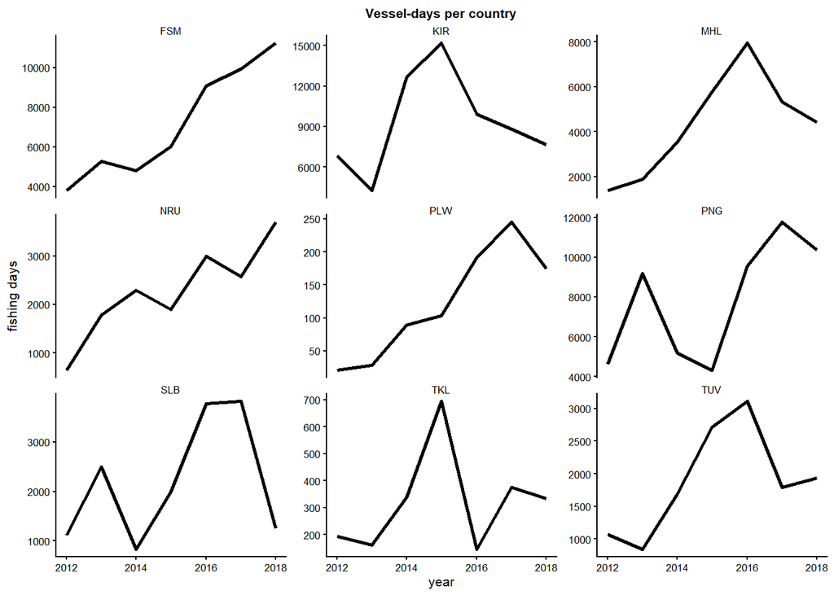

```r
ggplot(data = act, mapping = aes(x = year, y = days)) +
  geom_line() +
  facet_wrap(~eez_iso3, scales = "free_y") +
  labs(x = "year", y = "fishing days") +
  ggtitle("Vessel-days per country")
```

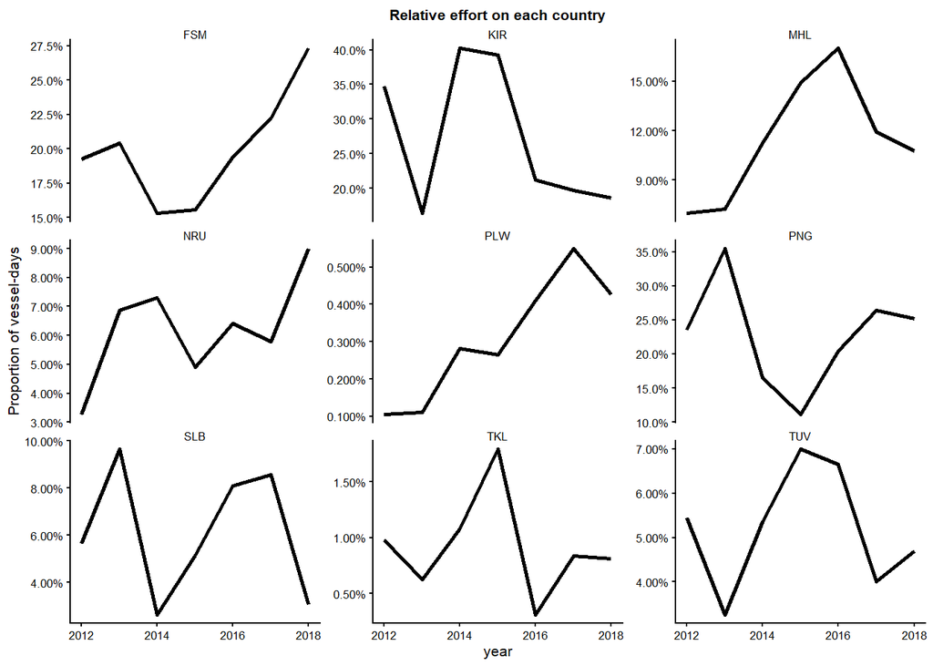

```r
ggplot(data = act, mapping = aes(x = year, y = days_prop)) +
  geom_line() +
  facet_wrap(~eez_iso3, scales = "free_y") +
  labs(x = "year", y = "fishing days") +
  ggtitle("Vessel-days per country") +
  scale_y_continuous(labels = scales::percent) +
  labs(x = "year", y = "Proportion of vessel-days") +
  ggtitle("Relative effort on each country")
```

#### Catch data

We can now use the FFA catch data for skipjack and estimate yearly catches by EEZ.

```r
# Read in the catch data
catches <- read.csv(here("raw_data", "FFA", "ps_skj_catches_spatial_timeseries.csv"),
                    stringsAsFactors = F) %>%
  gather(year, catches, -eez_iso3) %>%
  mutate(year = as.numeric(str_remove(year, "X"))) %>%
  filter(year > 2010) %>%
  mutate(
    PNA = eez_iso3 %in% VDS_countries,
    eez_iso3 = ifelse(PNA, eez_iso3, "HS")
  ) %>%
  group_by(year, eez_iso3) %>%
  summarize(catches = sum(catches))
```

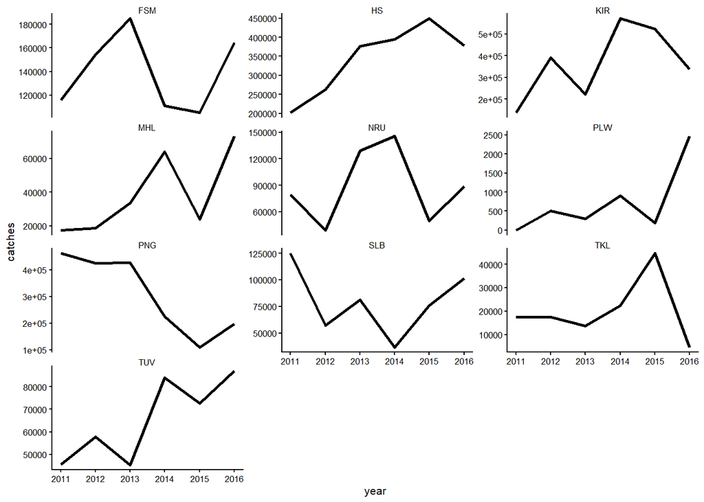

```r
ggplot(data = catches, mapping = aes(x = year, y = catches)) +
  geom_line() +
  facet_wrap(~eez_iso3, scales = "free_y", ncol = 3)
```

We can now take catches and divide them by effort to obtain annual CPUE for each EEZ.

```r
# Join both data
cpue <- left_join(act, catches, by = c("year", "eez_iso3")) %>%
  drop_na() %>%
  group_by(eez_iso3) %>%
  summarize(
    catches = sum(catches),
    days = sum(days)
  ) %>%
  mutate(cpue = catches / days) %>%
  arrange(desc(cpue)) %>%
  mutate(
    cpue_prop = cpue / (sum(cpue) / (1 - prop_hs)),
    cumsum_cpue_prop = cumsum(cpue_prop),
    eez_iso3 = fct_relevel(eez_iso3, "KIR")
  ) %>%
  arrange(eez_iso3)
```

Let’s take a look at the relationship between Effort and Catches:

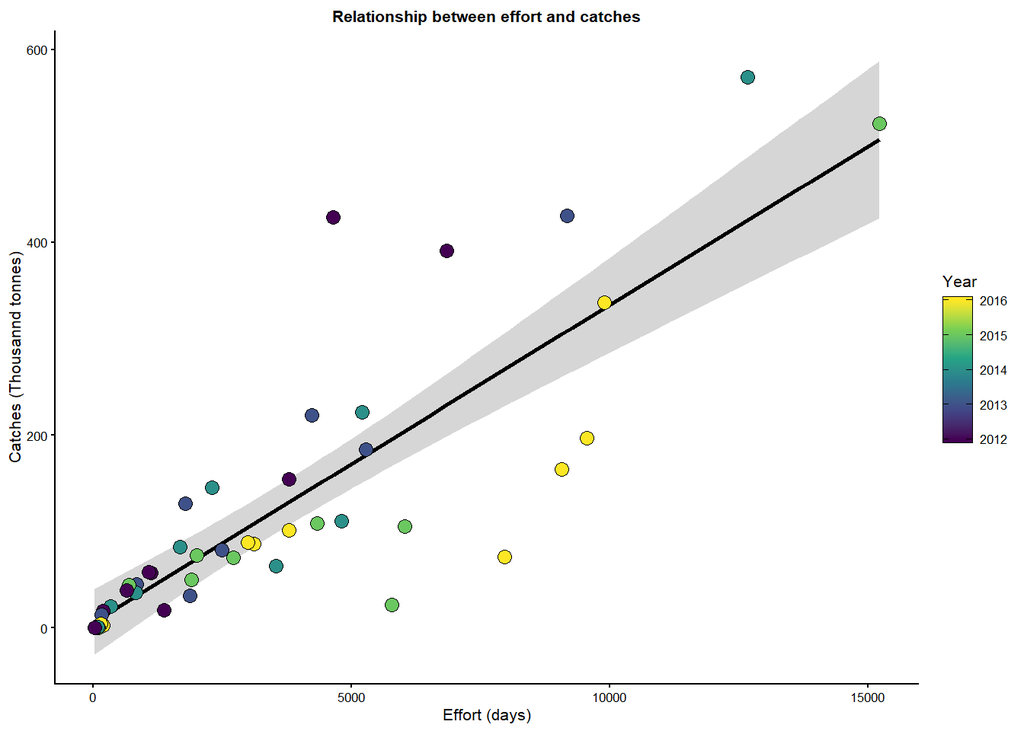

```r
(catch_effort_plot <- left_join(act, catches, by = c("year", "eez_iso3")) %>%
   drop_na() %>%
   ggplot(mapping = aes(x = days, y = catches / 1000, fill = year)) +
   geom_smooth(method = "lm", color = "black") +
   geom_point() +
   labs(x = "Effort (days)", y = "Catches (Thousannd tonnes)") +
   ggtitle("Relationship between effort and catches") +
   scale_fill_viridis_c() +
   guides(fill = guide_colorbar(title = "Year",
                                frame.colour = "black",
                                ticks.colour = "black")))
```

```r
ggsave(plot = catch_effort_plot,
       filename = here("docs", "slides", "img", "catch_effort_plot.png"),
       width = 4,
       height = 3)
```

```r
fvec_cpue <- c(cpue$cpue_prop, prop_hs)
fvec_cpue <- c(0.12, 0.08, 0.07, 0.13, 0.07, 0.12, 0.09, 0.12, 0.1, 0.1)
names(fvec_cpue) <- c(levels(cpue$eez_iso3), "HS")

# Chose a source for the fvec
bvec <- fvec_cpue # From CPUE data
# fvec <- fvec_h # From effort data
# Initial biomass distribution should be based on CPUE
# Then, biomass distribution vector should be based on area by EEZ (10 % to HS)
Xvec <- bvec * Bnow
names(fvec) <- names(bvec)
```

# Start checks

## Is there a value of $\bar{E}$ for the given possible ranges of Biomass?

The following plot shows the attainable levels of effort given price, catchability and biomass for cases where pi = 0. In other words, this just shows if harvesting at all would be profitable even in the absence of a vessel-day price.

The graph shows that for biomass levels between 1 ton and current Byomass (3.507028310^{6}), many values of $E$ are above $\bar{E}$ (horizontal dashed line)

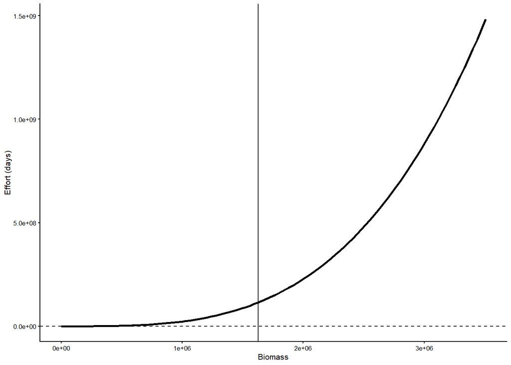

```r
tibble(X = seq(1, Bnow, length.out = 100)) %>%
  rowwise() %>%
  mutate(E = sum(max_Ei(p = p, q = q, Xvec = X, theta = theta, R = R, beta = beta, c = c))) %>%
  ggplot(aes(x = X, y = E)) +
  geom_line() +
  geom_vline(xintercept = Bmsy) +
  geom_hline(yintercept = E, linetype = "dashed") +
  labs(x = "Biomass", y = "Effort (days)")
```

For 95% of the values of biomass, there are attainable levels of effort that would produce positive catches.

```r
tibble(X = seq(1, Bnow, length.out = 100)) %>%
  rowwise() %>%
  mutate(E_calc = sum(max_Ei(p = p, q = q, Xvec = X, theta = theta, R = R, beta = beta, c = c)),
         Eabove = E_calc > E) %$%
  sum(Eabove)
```

```
## [1] 95
```

## What’s the aggregate demand for a given value of pi with Bmsy?

First we need to establish the maximum chargable price to plot all ranges from 0 to max_pi.

```r
max_pi <- max((p * q * Bnow * fvec))
```

For given values, the maximum chargable price for VDS is 1.3210^{4}. Let’s create a dataframe with this data. This data.frame essentially contains the demand curves for each country, based on the biomass in each patch. Biomass comes from the cpue vector we derived.

```r
check_E_pi <- tibble(pi = seq(0, max_pi, length.out = 100)) %>%
  rowwise() %>%
  mutate(E = list(
    tibble(
      E = E_vec_fxn(p = p, q = q, Xvec = 0.9 * Xvec, pi = pi, theta = theta, R = R, beta = beta, c = c),
      cty = names(fvec),
      cty2 = as.character(1:length(fvec))
    )
  )) %>%
  unnest() %>%
  filter(!cty == "HS")
```

The following graph shows all the demand curves for each country, given a value of E. The vertical dashed line shows the $\bar{E}$. Its intersections with each demand curve tell us how much vessels would be willing to pay to fish in each country.

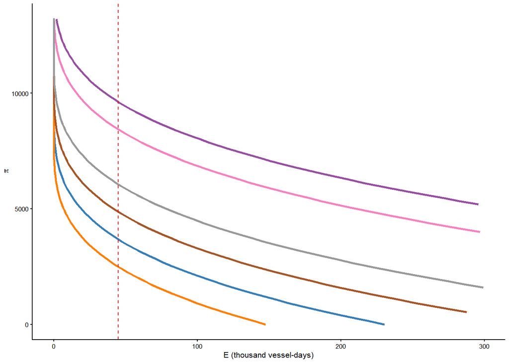

```r
(demands <- ggplot(data = filter(check_E_pi, E < 300000),
                   mapping = aes(x = E / 1000, y = pi, color = cty2)) +
   geom_line(size = 1) +
   geom_vline(xintercept = E / 1000, color = "red", linetype = "dashed") +
   labs(x = "E (thousand vessel-days)", y = quo(pi)) +
   guides(color = guide_legend("Patch", ncol = 2)) +
   theme(legend.position = "none") +
   scale_color_brewer(palette = "Set1")
   )
```

We can aggregate all these demand curves horizontally and obtain the total demand curve. This is essentially the curve along wich we want to find the optimal pi.

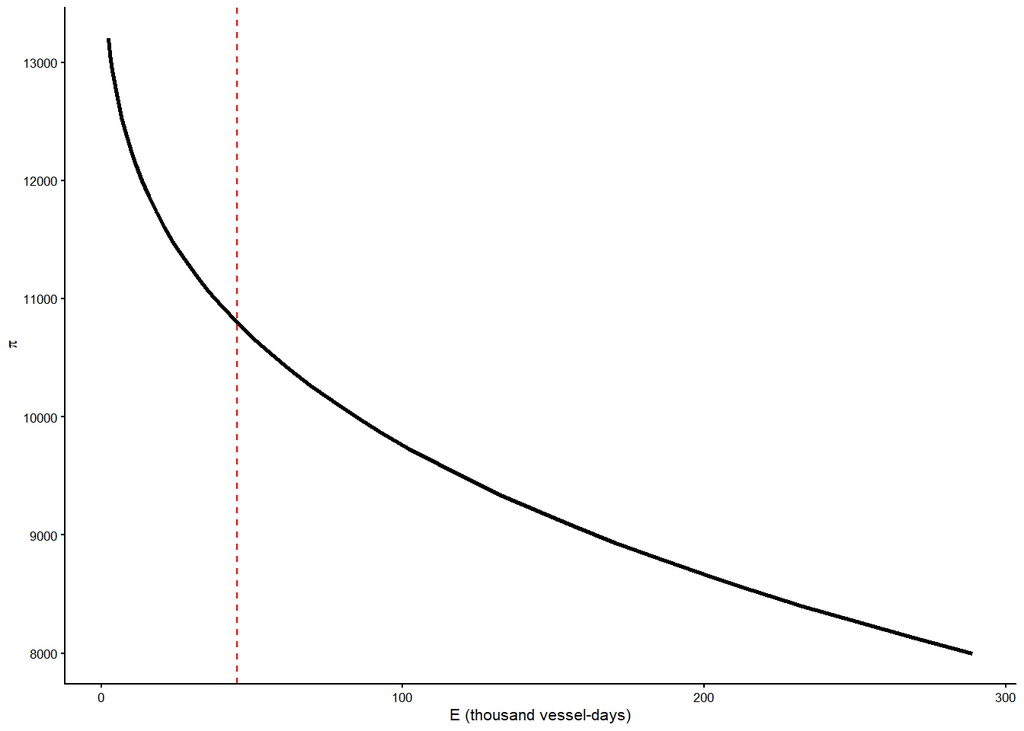

```r
(demands_agg <- check_E_pi %>%
   group_by(pi) %>%
   summarise(E = sum(E)) %>%
   ungroup() %>%
   filter(E < 300000) %>%
   ggplot(aes(x = E / 1000, y = pi)) +
   geom_line() +
   geom_vline(xintercept = E / 1000, color = "red", linetype = "dashed") +
   labs(x = "E (thousand vessel-days)", y = quo(pi))
 )
```

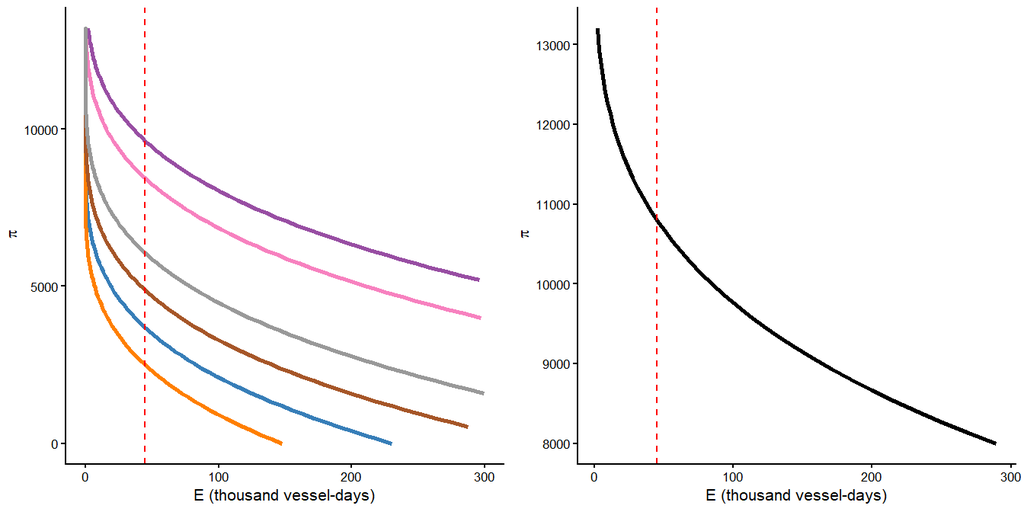

```r
(demand_curves <- plot_grid(demands, demands_agg, ncol = 2))
```

```r
ggsave(plot = demand_curves,
       filename = here("docs", "slides", "img", "demand_curves.png"),
       width = 4,
       height = 2)
```